# Question

The canonical example of [simple harmonic motion](https://en.wikipedia.org/wiki/Simple_harmonic_motion) is a mass-spring system. A lightweight spring is attached to a ceiling, and a moderately heavy mass is attached to the dangling end. If the mass is pulled away from its resting elevation, and released, the weight will bounce up and down, approximately following a sinusoidal function in time. By placing the mass-spring system close to a marked wall, and by using a camera with a long [focal length](https://en.wikipedia.org/wiki/Focal_length#In_photography), the position (in meters above floor) of the mass was tracked over time (in seconds).

Of course, in order to exactly follow a sinusoidal path through time, a few unrealistic assumptions need to be true. There should be no friction (no air resistance nor internal resistance of the bending spring). Also, the spring should exactly follow [Hooke’s law](https://en.wikipedia.org/wiki/Hooke%27s_law).

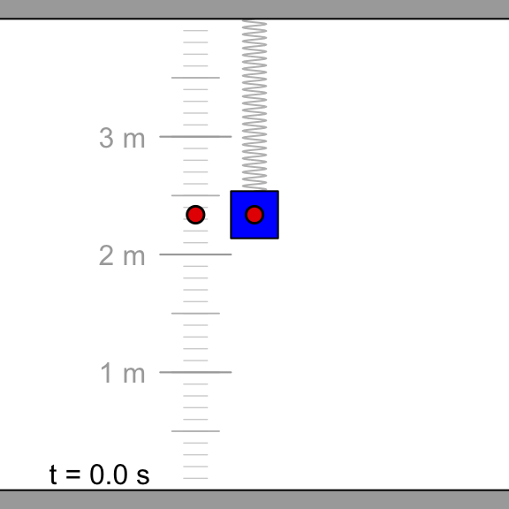

After capturing the video, elevation measurements were recorded every 0.1 seconds over an interval of 5 seconds.

| $t$ (time in seconds) | $y$ (height in meters) |
| --- | --- |
| 0.0 | 2.35 |
| 0.1 | 2.26 |
| 0.2 | 1.91 |
| 0.3 | 1.59 |
| 0.4 | 1.12 |
| 0.5 | 0.78 |
| 0.6 | 0.59 |
| 0.7 | 0.67 |
| 0.8 | 0.89 |
| 0.9 | 1.24 |
| 1.0 | 1.62 |
| 1.1 | 2.01 |
| 1.2 | 2.24 |
| 1.3 | 2.33 |
| 1.4 | 2.19 |
| 1.5 | 1.85 |
| 1.6 | 1.44 |
| 1.7 | 1.04 |
| 1.8 | 0.74 |
| 1.9 | 0.58 |
| 2.0 | 0.66 |
| 2.1 | 0.93 |
| 2.2 | 1.34 |
| 2.3 | 1.73 |
| 2.4 | 2.08 |
| 2.5 | 2.32 |
| 2.6 | 2.36 |
| 2.7 | 2.13 |
| 2.8 | 1.82 |
| 2.9 | 1.35 |
| 3.0 | 0.98 |
| 3.1 | 0.66 |
| 3.2 | 0.59 |
| 3.3 | 0.67 |
| 3.4 | 1.01 |
| 3.5 | 1.43 |
| 3.6 | 1.82 |
| 3.7 | 2.11 |
| 3.8 | 2.29 |
| 3.9 | 2.27 |
| 4.0 | 2.05 |
| 4.1 | 1.70 |
| 4.2 | 1.32 |
| 4.3 | 0.90 |
| 4.4 | 0.66 |
| 4.5 | 0.62 |
| 4.6 | 0.79 |
| 4.7 | 1.07 |
| 4.8 | 1.48 |
| 4.9 | 1.87 |
| 5.0 | 2.16 |

1. Run a sinusoidal regression on the data.
2. The regression will have the form $y = A\sin(Bt+C)+D$, where the parameters are $A$, $B$, $C$, and $D$, which are the amplitude, [angular frequency](https://en.wikipedia.org/wiki/Angular_frequency), phase shift, and vertical offset (or midline constant).
3. Using the angular frequency, calculate the [period](https://en.wikipedia.org/wiki/Periodic_function) ($P$) using $P=\frac{2\pi}{B}$.

Using the process outlined above, report the period of the best-fit curve. The tolerance is $\pm 0.001$ seconds.

# Solution

1. Copy and paste data into a [Desmos](https://www.desmos.com/calculator) expression.
2. Click the `Add Regression` icon.
3. Choose `Sinusoidal Regression`.
4. The best-fit curve has four parameters:
   $$y~=~0.86539\cdot
   \sin(4.90944t+1.58377)+1.46611$$
5. Recognize that the angular frequency is the multiplier inside the argument.
   $$B=4.90944$$
6. Use the formula to calculate the period from the angular frequency. (This formula is always the same.)
   $$P~=~\frac{2\pi}{B}$$
   $$P~=~\frac{2\pi}{4.90944}$$
   $$P~=~1.2798$$

# Meta-information

extype: num exsolution: 1.2798176 exname: mass_spring_period extol: 0.001